# Air France Internet Marketing

## DATA VISUALIZATIONS

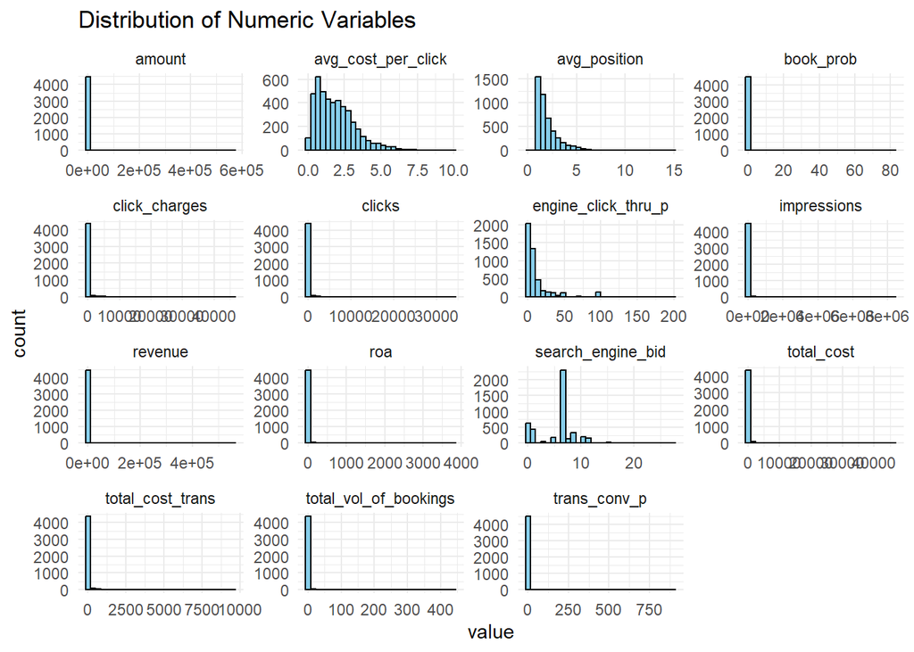

```r
# 1. Distribution of numeric variables
full.data %>%
  select_if(is.numeric) %>%
  gather(key = "variable", value = "value") %>%
  ggplot(aes(x = value)) + facet_wrap(~variable, scales = "free") +
  geom_histogram(bins = 30, fill = "skyblue", color = "black") +
  theme_minimal() + labs(title = "Distribution of Numeric Variables")
```

ANALYSIS: Most of the variables display highly skewed distributions, with a concentration of values at the lower side and a long tail towards the higher end. This indicates that there are a few very high-value outliers compared to a majority of lower-value data points.The histogram for avg_cost_per_click shows a spread of values with a peak and then a gradual decline. But there are variations that could be explored to optimize bidding strategies. The histogram for avg_position shows that most ads are placed within first few positions. The histogram for engine_click_thru_p indicates that there are many values close to zero. This could mean that several ads or keywords have low click through rate.The histogram for search_engine_bid depicts a concentration of bids within lower range, with less concentration around high values. This indicates less expensive keywords are targeted or using conservative bidding strategy.

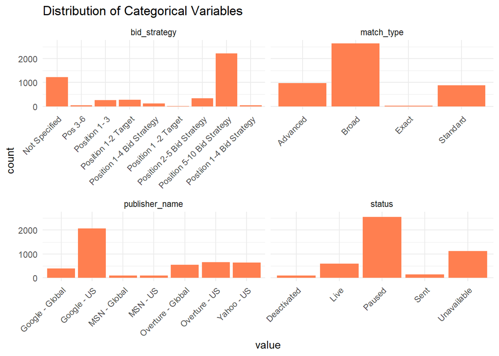

```r
# 2. Distribution of categorical variables
full.data %>%
  select('publisher_name', 'match_type', 'bid_strategy', status) %>%
  gather(key = "variable", value = "value") %>%
  ggplot(aes(x = value)) +
  facet_wrap(~variable, scales = "free_x") +
  geom_bar(fill = "coral") +
  theme_minimal() +
  theme(axis.text.x = element_text(angle = 45, hjust = 1)) +
  labs(title = "Distribution of Categorical Variables")
```

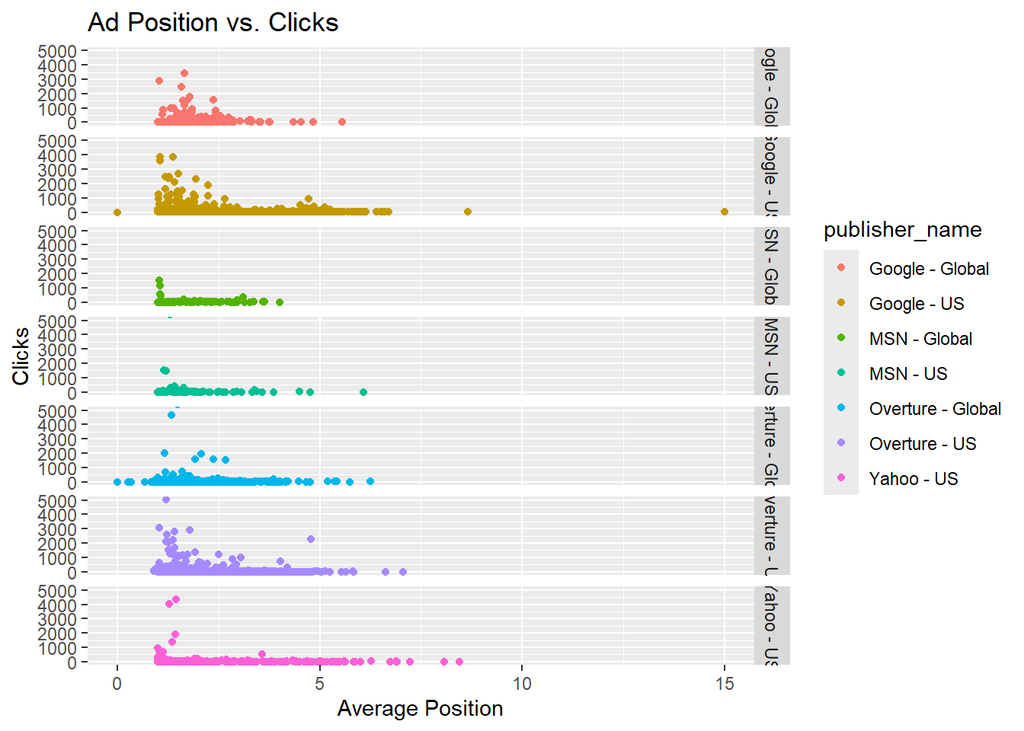

```r
# 3. Relationship between Ad position and clicks by Publisher Name
ggplot(full.data, aes(x = `avg_position`, y = clicks)) +
  geom_point(aes(color = `publisher_name`)) + coord_cartesian(ylim = c(0, 5000)) +
  labs(title = "Ad Position vs. Clicks", x = "Average Position", y = "Clicks")+ facet_grid(`publisher_name`~.)
```

ANALYSIS: The plot uses different colors to represent different publishers, showing a direct comparison of performance. Most of clicks tend to cluster towards the lower numerical values, which is consistent with the industry understanding that ads in top positions generally receive more clicks. The variation in click patterns among different publishers, suggests that each publisher’s platform perform differently. Certain publishers show a strong correlation between top ad positions and high click numbers. It may prove to be beneficial to prioritize those publishers and bid more aggressively for top positions.

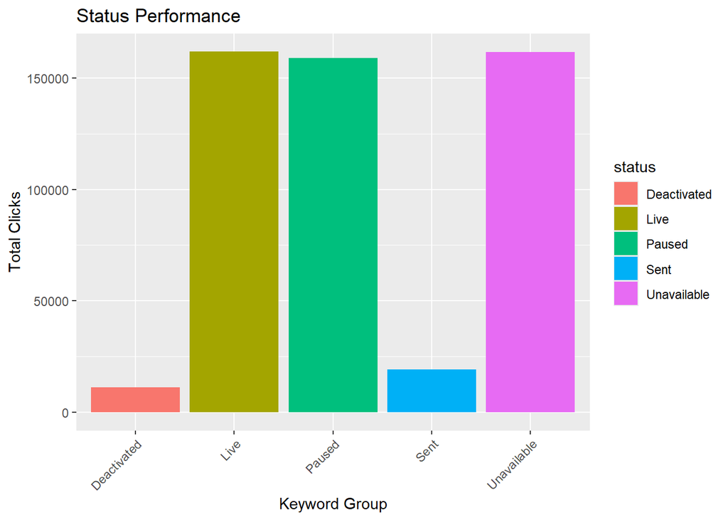

```r
# 4. Relationship between the total clicks for different Status.
full.data %>%
  group_by(status) %>%
  summarise(Total_Clicks = sum(clicks)) %>%
  ggplot(aes(x = status, y = Total_Clicks, fill = status)) +
  geom_bar(stat = "identity") +
  theme(axis.text.x = element_text(angle = 45, hjust = 1)) +
  labs(title = "Status Performance", x = "Keyword Group", y = "Total Clicks")
```

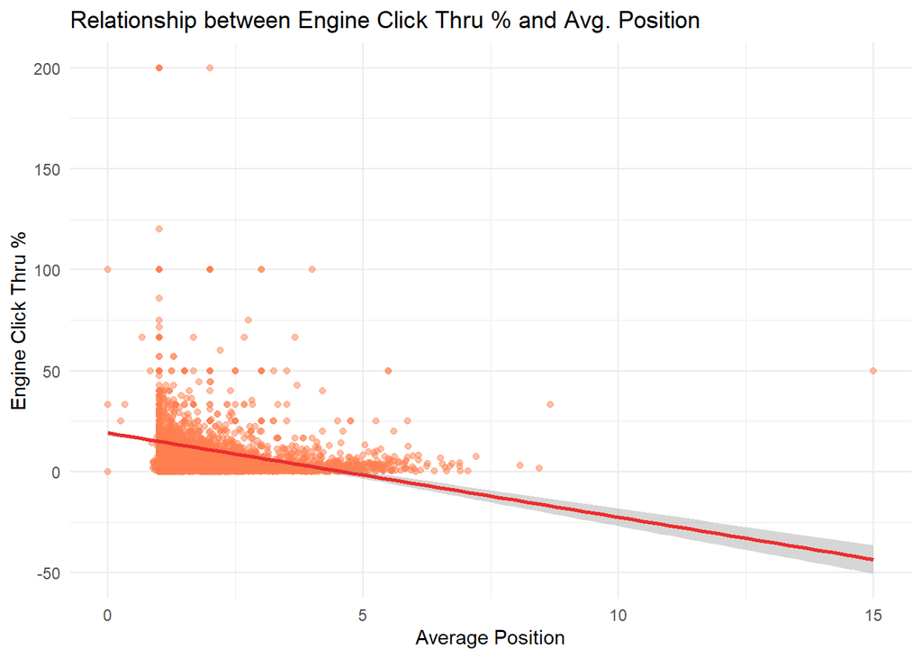

```r
# 5. Relationship between Average Position and Engine click through rate
ggplot(full.data, aes(x = `avg_position`, y = `engine_click_thru_p`)) +
  geom_point(colour = 'coral',alpha = 0.5) +
  geom_smooth(method = lm, color = "firebrick2") +  # Add a linear regression line
  theme_minimal() +
  labs(title = "Relationship between Engine Click Thru % and Avg. Position",
       x = "Average Position",
       y = "Engine Click Thru %")
```

ANALYSIS: The plot suggests an inverse relationship where a lower ‘Average Position’ number,generally correlates with a higher ‘Engine Click Through %’.Ads that appear closer to the top are more likely to be clicked, implying that these positions are more valuable for increasing visibility and driving traffic. There are some outliers that indicate that some ads in lower position still achieve high click_through rates. This could be due to relevance of ad content or keywords.The click-through rates can vary widely for similar ad positions. This could be due to specific search query or cometition at time. Strategically targeting higher ad positions could improve click-through rates, but it is also essential to consider the cost associated with these positions and the overall return on investment.

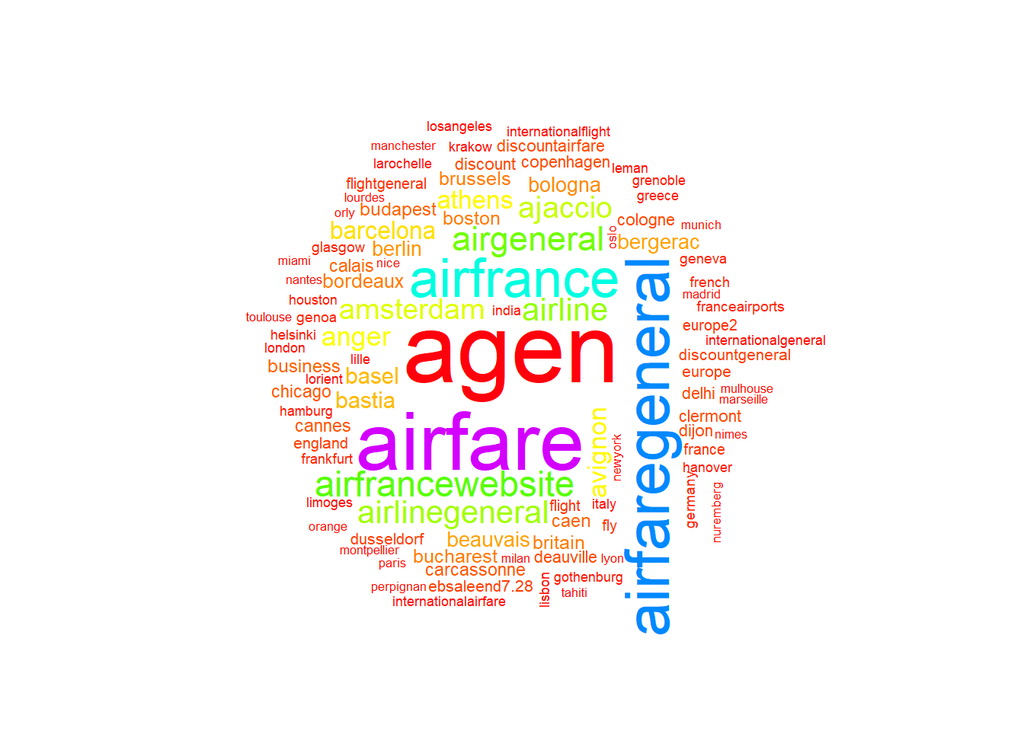

```r
# 6. Word Cloud of Category column without uncategorized values
# Prepare the 'Category' column, and convert to a character vector
full.data$category <- as.character(full.data$category)

# Exclude the 'uncategorised' entries
full.data <- full.data[!tolower(full.data$category) == 'uncategorized', ]

# Create a frequency table of the categories
category_freq <- table(full.data$category)

# Set colors (optional, customize as desired)
set.seed(123)  # For reproducibility
colors <- rainbow(nrow(category_freq))

# Create the wordcloud
wordcloud(names(category_freq), sort(category_freq, decreasing = TRUE),
         min.freq = 1, colors = colors, max.words=100, random.order=FALSE)
```

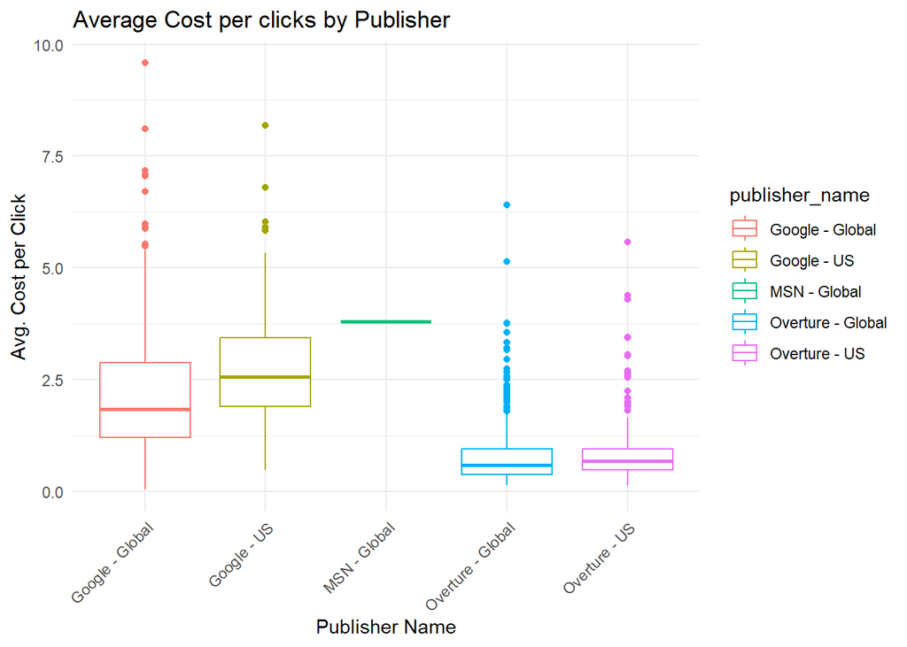

```r
# 7. Distribution of average cost per clicks per publisher
ggplot(full.data, aes(x = `publisher_name`, y = `avg_cost_per_click`, color = `publisher_name`)) +
  geom_boxplot() +
  theme_minimal() +
  theme(axis.text.x = element_text(angle = 45, hjust = 1)) +
  labs(title = "Average Cost per clicks by Publisher", x = "Publisher Name", y = "Avg. Cost per Click")
```

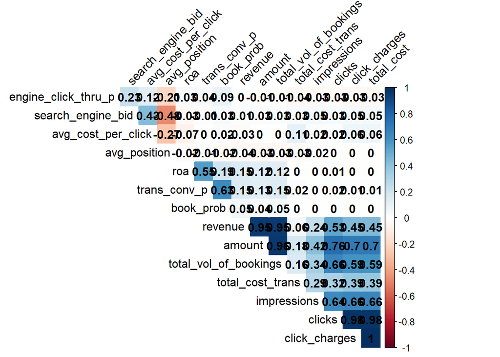

```r
# 8. Correlation heatmap
## Analysis of Correlation Between Variables

# filtering out the numeric data for correlation
numeric_data <- full.data[, sapply(full.data, is.numeric)]

# This selects rows where all columns have values
all_complete <- complete.cases(numeric_data)

# Select all columns from those rows
numeric_data_complete <- numeric_data[all_complete,]

# Calculate the correlation matrix
cor_matrix <- cor(numeric_data_complete)

# Plotting the correlation heatmap
corrplot(cor_matrix, method = "color", type = "upper", order = "hclust",
         addCoef.col = "black", # Add correlation coefficients
         tl.col = "black", tl.srt = 45, # Text label color and rotation
         diag = FALSE) # Exclude the diagonal
```